# Homework_2

oluwayemisi_olokeogun

2022-10-10

NSID: yaq076

Email: ya76@mail.usask.ca

# Part 1: Create some simulated data and fit simple linear regression models to it

## 1.1 Create a vector, x, containing 100 observations drawn from a N(0, 1) distribution

```r
set.seed(100)
X <- rnorm(100, mean = 0, sd = 1)
```

## 1.2 Create a vector, eps, containing 100 observations drawn from a N(0, 0.5) distribution

```r
set.seed(100)
eps <- rnorm(100, mean = 0, sd = 0.5)
```

## 1.3 Generate a vector y according to the model

```r
a_inter<-(-1)
e_vector<-(eps)
s_slope<-(0.5)
slo_X<-((s_slope)*(X))
y<-a_inter+slo_X+e_vector
```

## 1.4 A scatterplot displaying the relationship between x and y

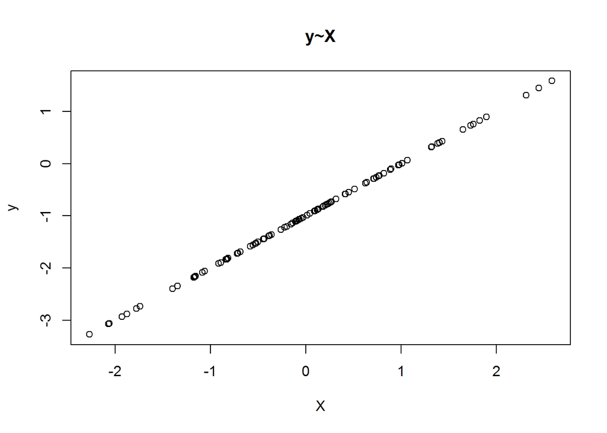

```r
library(ggplot2)
plot(x=X,y=y,main="y~X")
```

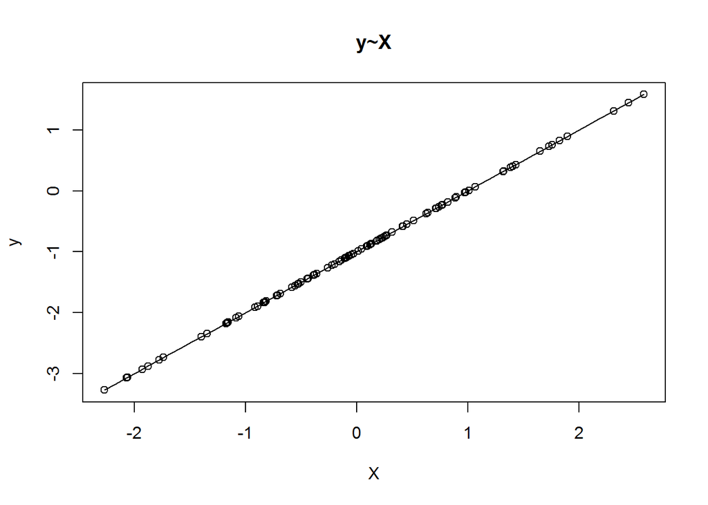

```r
scatter.smooth(x=X,y=y,main="y~X")
```

The relationship between x and y is known as a positive association because it forms a pattern of dots in a line sloping upward

## 1.5 Fit a least squares linear model to predict y using x

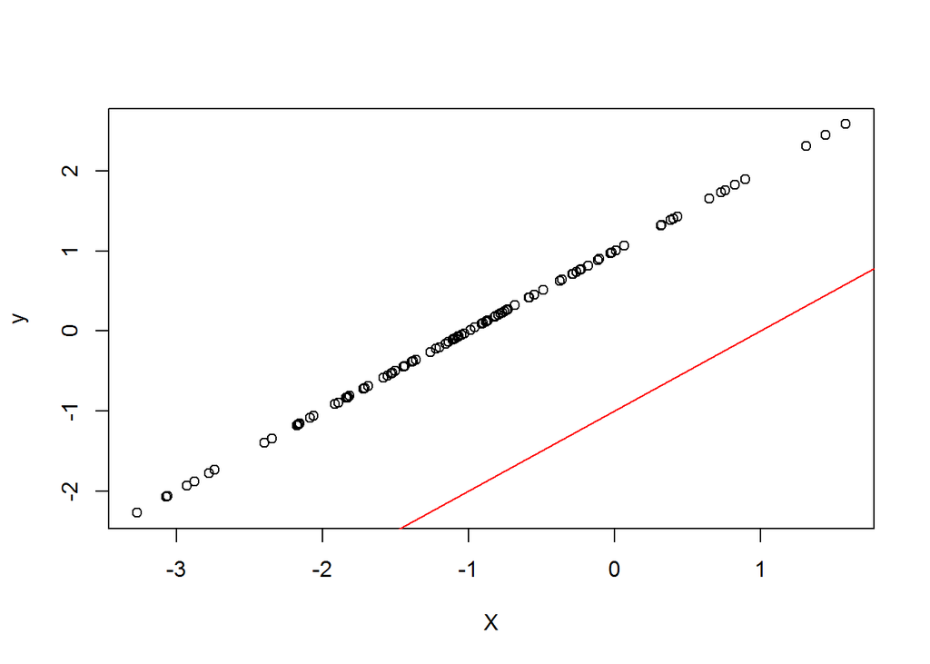

```r
myfit <- lm(y~X)
plot(y, X, xlab="X", ylab = "y")
abline(myfit$coef, col = "red")
```

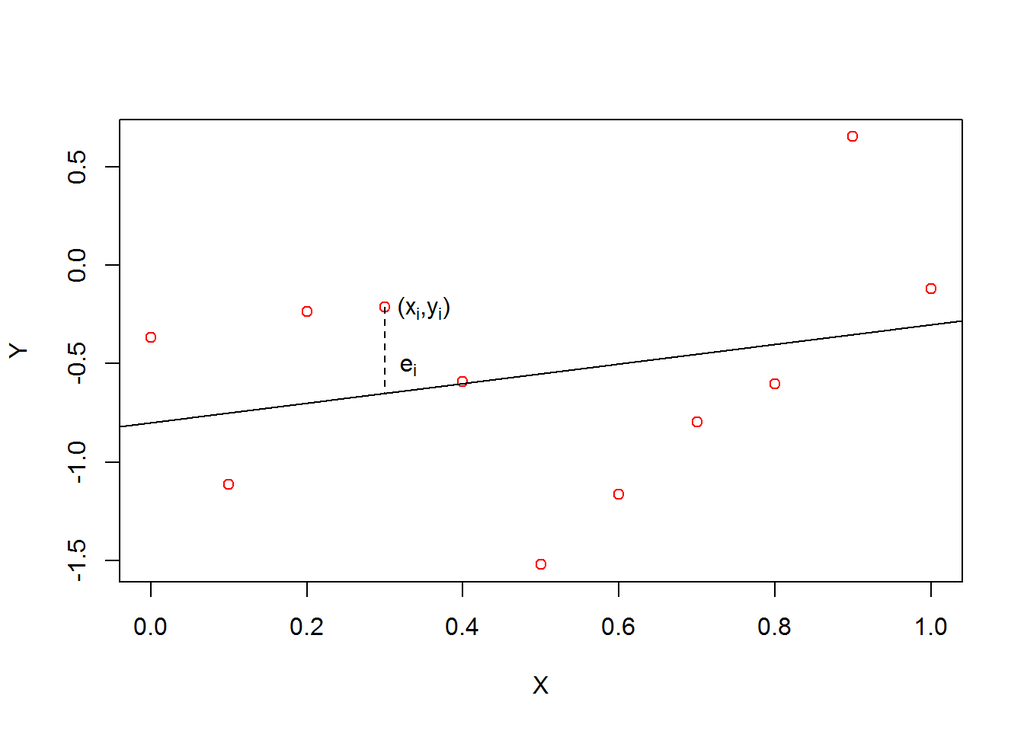

```r
myx <- seq(0, 1, by = 0.1)
set.seed(0)
mye <- rnorm(length(myx), 0, 0.5)
beta0 <- -1
beta1 <- 0.5
myy <- beta0 + beta1*myx + mye
mymodel <- lm(myy ~ myx)
plot(myx, myy, col = "red", ylab = "Y", xlab = "X")
abline(coef(mymodel))
text( myx[4] + 0.05, myy[4], expression(paste("("*x[i]*","*y[i]*")")) )
segments(myx[4], myy[4], myx[4], coef(mymodel)%*%t(t(c(1, myx[4]))), lty = 2)
text( myx[4] + 0.03, myy[4]-0.3, expression(e[i]))
```

## 1.8 Data generation process with less noise in the data (Repeat a - f)

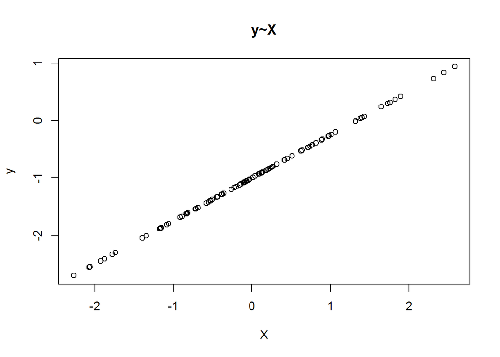

```r
set.seed(100)
X <- rnorm(100, mean = 0, sd = 1)

set.seed(100)
eps <- rnorm(100, mean = 0, sd = 0.25)


a_inter<-(-1)
e_vector<-(eps)
s_slope<-(0.5)
slo_X<-((s_slope)*(X))
y<-a_inter+slo_X+e_vector

library(ggplot2)
plot(x=X,y=y,main="y~X")
```

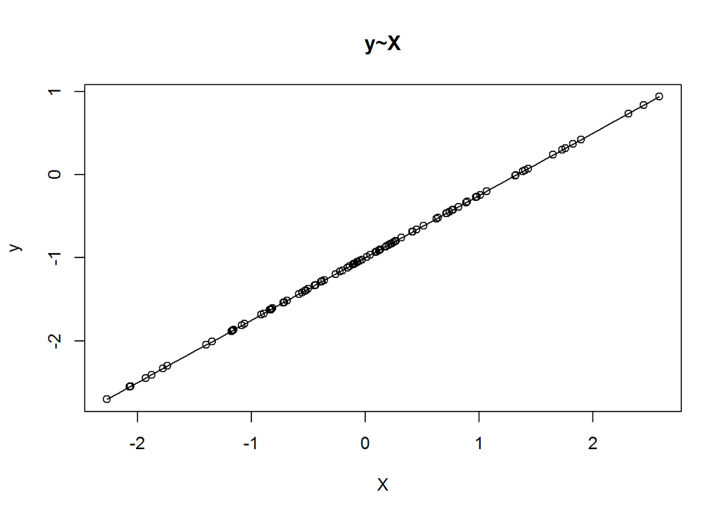

```r
scatter.smooth(x=X,y=y,main="y~X")
```

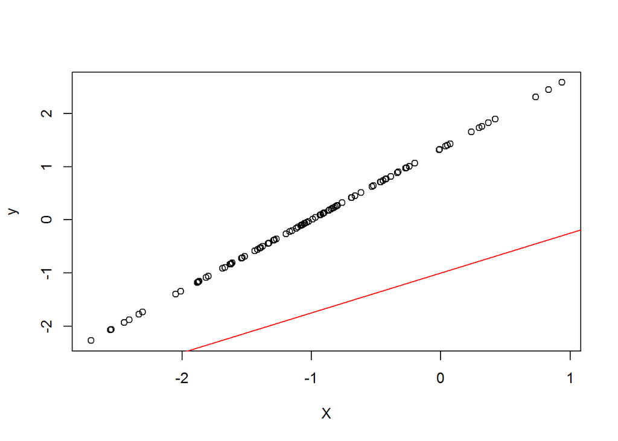

```r
myfit <- lm(y~X)
plot(y, X, xlab="X", ylab = "y")
abline(myfit$coef, col = "red")
```

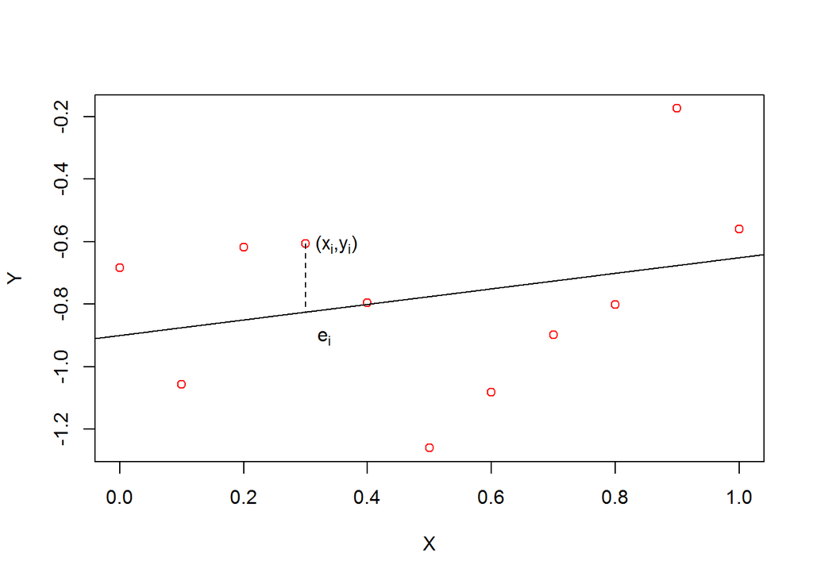

```r
myx <- seq(0, 1, by = 0.1)
set.seed(0)
mye <- rnorm(length(myx), 0, 0.25)
beta0 <- -1
beta1 <- 0.25
myy <- beta0 + beta1*myx + mye
mymodel <- lm(myy ~ myx)
plot(myx, myy, col = "red", ylab = "Y", xlab = "X")
abline(coef(mymodel))
text( myx[4] + 0.05, myy[4], expression(paste("("*x[i]*","*y[i]*")")) )
segments(myx[4], myy[4], myx[4], coef(mymodel)%*%t(t(c(1, myx[4]))), lty = 2)
text( myx[4] + 0.03, myy[4]-0.3, expression(e[i]))
```

## 1.9 Data generation process with more noise in the data (Repeat a - f)

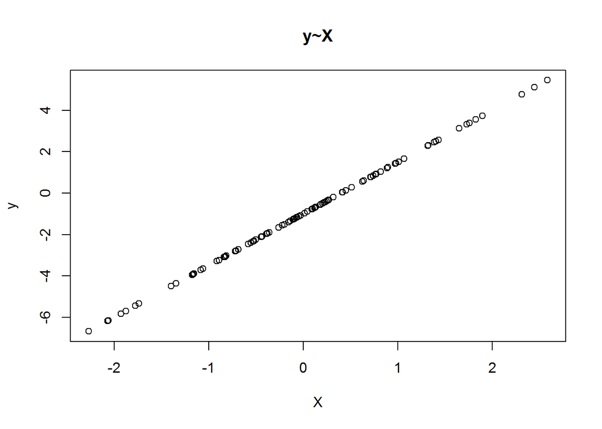

```r
set.seed(100)
X <- rnorm(100, mean = 0, sd = 1)

set.seed(100)
eps <- rnorm(100, mean = 0, sd = 2)


a_inter<-(-1)
e_vector<-(eps)
s_slope<-(0.5)
slo_X<-((s_slope)*(X))
y<-a_inter+slo_X+e_vector

library(ggplot2)
plot(x=X,y=y,main="y~X")
```

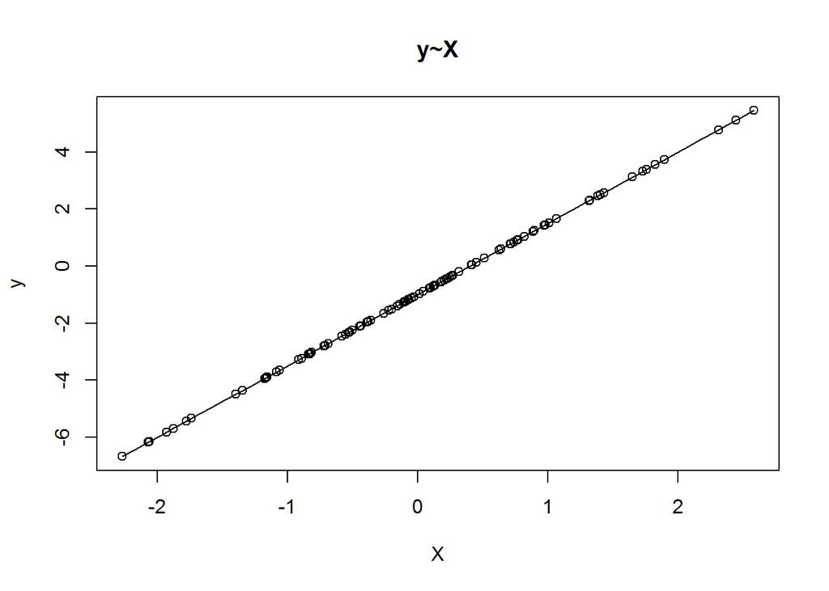

```r
scatter.smooth(x=X,y=y,main="y~X")
```

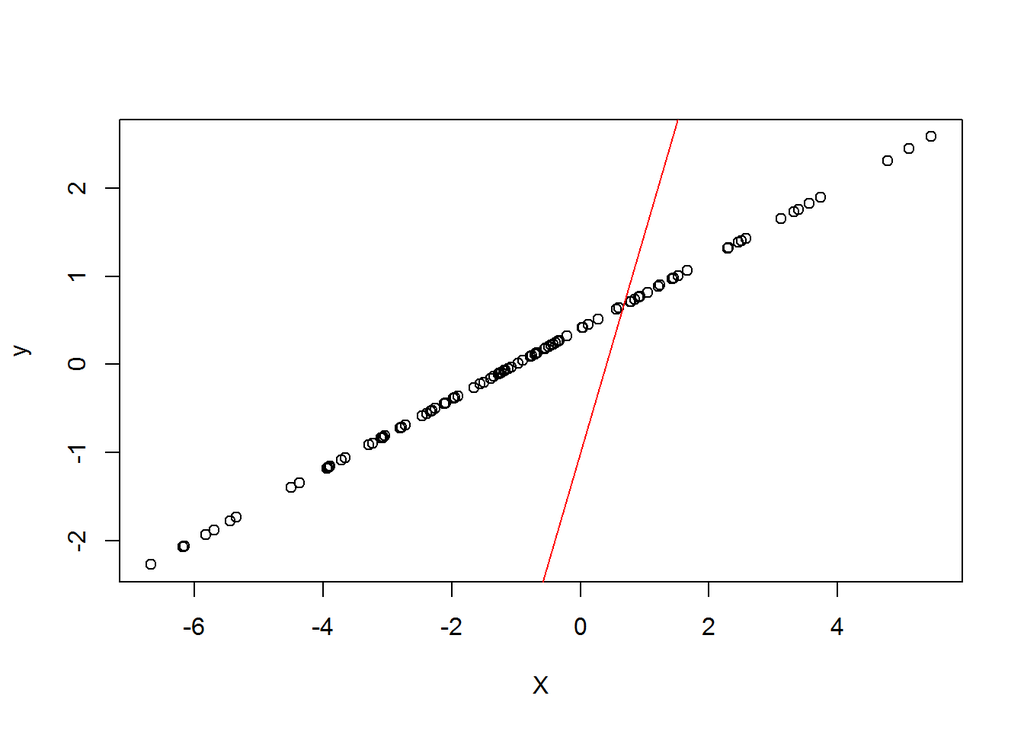

```r
myfit <- lm(y~X)
plot(y, X, xlab="X", ylab = "y")
abline(myfit$coef, col = "red")
```

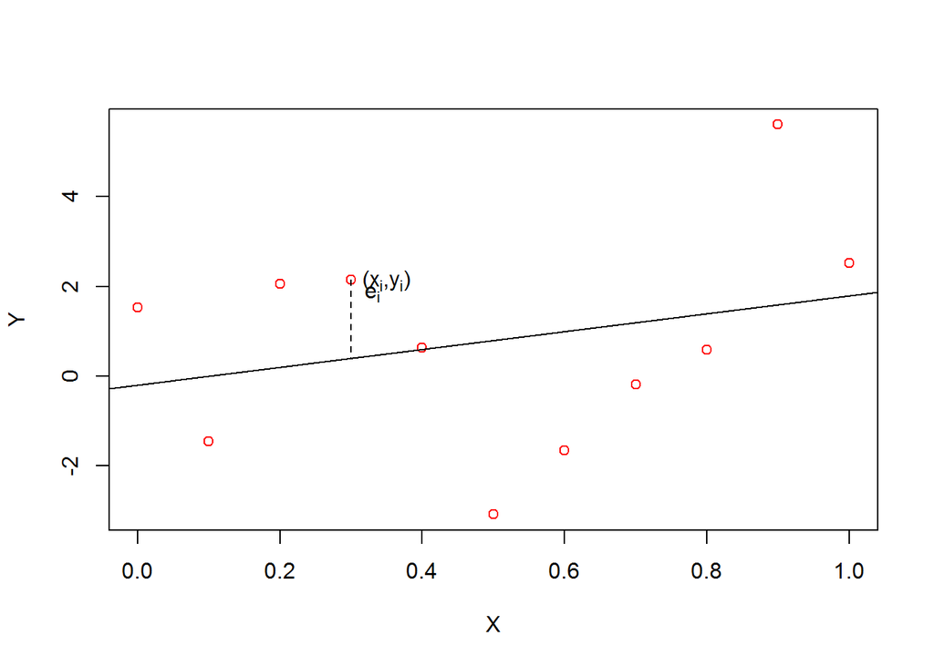

```r
myx <- seq(0, 1, by = 0.1)
set.seed(0)
mye <- rnorm(length(myx), 0, 2)
beta0 <- -1
beta1 <- 2
myy <- beta0 + beta1*myx + mye
mymodel <- lm(myy ~ myx)
plot(myx, myy, col = "red", ylab = "Y", xlab = "X")
abline(coef(mymodel))
text( myx[4] + 0.05, myy[4], expression(paste("("*x[i]*","*y[i]*")")) )
segments(myx[4], myy[4], myx[4], coef(mymodel)%*%t(t(c(1, myx[4]))), lty = 2)
text( myx[4] + 0.03, myy[4]-0.3, expression(e[i]))
```

# Part 2: The use of multiple linear regression on the Auto data set.

install.packages(“ISLR”)

```r
library(ISLR)
data(Auto)
```

## 2.1 A scatterplot matrix

```r
df <- head(Auto)
print(df)
```

```
##   mpg cylinders displacement horsepower weight acceleration year origin
## 1  18         8          307        130   3504         12.0   70      1
## 2  15         8          350        165   3693         11.5   70      1
## 3  18         8          318        150   3436         11.0   70      1
## 4  16         8          304        150   3433         12.0   70      1
## 5  17         8          302        140   3449         10.5   70      1
## 6  15         8          429        198   4341         10.0   70      1
##                        name
## 1 chevrolet chevelle malibu
## 2         buick skylark 320
## 3        plymouth satellite
## 4             amc rebel sst
## 5               ford torino
## 6          ford galaxie 500
```

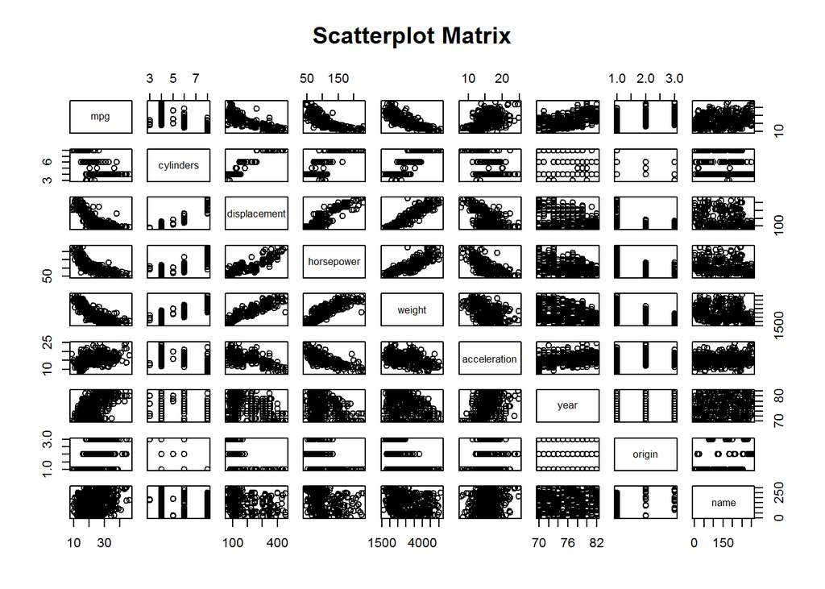

```r
pairs(~mpg + cylinders + displacement + horsepower + weight + acceleration + year + origin + name, data = Auto,
      main = "Scatterplot Matrix")
```

## 2.2 Matrix of correlations between the variables using the function cor()

```r
mydata = (Auto[c("mpg", "cylinders", "displacement", "horsepower", "weight", "acceleration", "year", "origin")])
mydata.cor = cor(mydata)
View(mydata.cor)
```

[output not shown]

## 2.3 Use the lm() function to perform a multiple linear regression with mpg as the response and all other variables except name as the predictors

```r
fit_m<-lm(mpg~cylinders+displacement+horsepower+weight+acceleration+year+origin,data=Auto)
summary(fit_m)
```

```
##
## Call:
## lm(formula = mpg ~ cylinders + displacement + horsepower + weight +
##     acceleration + year + origin, data = Auto)
##
## Residuals:
##     Min      1Q  Median      3Q     Max
## -9.5903 -2.1565 -0.1169  1.8690 13.0604
##
## Coefficients:
##                Estimate Std. Error t value Pr(>|t|)
## (Intercept)  -17.218435   4.644294  -3.707  0.00024 ***
## cylinders     -0.493376   0.323282  -1.526  0.12780
## displacement   0.019896   0.007515   2.647  0.00844 **
## horsepower    -0.016951   0.013787  -1.230  0.21963
## weight        -0.006474   0.000652  -9.929  < 2e-16 ***
## acceleration   0.080576   0.098845   0.815  0.41548
## year           0.750773   0.050973  14.729  < 2e-16 ***
## origin         1.426141   0.278136   5.127 4.67e-07 ***
## ---
## Signif. codes:  0 '***' 0.001 '**' 0.01 '*' 0.05 '.' 0.1 ' ' 1
##
## Residual standard error: 3.328 on 384 degrees of freedom
## Multiple R-squared:  0.8215, Adjusted R-squared:  0.8182
## F-statistic: 252.4 on 7 and 384 DF,  p-value: < 2.2e-16
```

1. There is a relationship between the predictors and the response
2. Predictors such as displacement, weight, year, and origin appear to have a statistically significant relationship to the response